# Components of Graphics

Daniel Kaplan

May 14, 2014

## The Grammar of Graphics

When you hear the word “grammar,” you likely think of the rules you studied when learning English or another natural language. It may be surprising (and maybe disappointing) that there are grammars of graphics. These graphics impose a provide a way to think about how meaningful new graphics can be created, just as natural language grammars help in forming new meaningful sentences.

Since everyone reading this knows something about English grammar, it’s sensible to explain how there could be a grammar of graphics by using English to introduce the concepts.

As you know, in English there are different parts of speech: nouns, verbs, adjectives, adverbs, noun phrases, etc. Part of English grammar explains how parts of speech can be put together in a meaningful way. For instance, here is a grammatically correct sentence:

> “Four horses pulled the king’s carriage.”

And here is an incorrect sentence with the same words:

> “Carriage’s king horses for the pulled.”

Each of the individual words is correct, but they way they are put together is not.

Some of the rules of grammar displayed in “Four horses pulled the king’s carriage”:

- Sentence structure: a subject and a verb. Some verbs — the transitive verbs — also require an object. Here: subject … transitive verb … object
- Subject: a noun or noun phrase. Here: “Four horses”: adjective … noun
- Object: a noun or noun phrase. Here: “the king’s carriage”

Dividing the sentence up by the parts of speech makes it easy to think about new sentences, which might have more or less detail:

> “Horses pulled the carriage.”

> “Four weary old horses reluctantly dragged the worn-out carriage.”

The presence or absence of modifiers like “weary” changes the meaning and expressiveness of the sentence. You can even think about alternative stories altogether:

> “An engine pushes the boat.”

| Subject | Verb | Object |
| --- | --- | --- |
| Four horses | pulled | the king’s carriage |
| Horses | pulled | the carriage |
| The wind | pushed | the boat |

Pick one subject, one verb, and one object and you will have a meaningful sentence although it may not be factually correct or tell the story that you want to tell.

A grammar of graphics has been proposed [Wilkinson, L. (2005),The Grammar of Graphics(2nd ed.). Statistics and Computing, New York: Springer] and extended by Wickham [Wickham, [A layered grammar of graphics](http://mimno.infosci.cornell.edu/info3300/readings/layered-grammar.pdf)] that enables graphics to be described in layers so they can be built incrementally. The software you will be using to construct graphics is called `ggplot2`, but before showing how to use that software, you should learn some of the “parts of speech” of graphics. Here are five of them.

1. Data : cases and variables
2. Frame : a set of data variables defining a space
3. Layer: glyphs drawn to represent data cases
4. Scales: how each variable appears visually
5. Guides: presentation of scales and other orienting information to the user

### Data

You already know what you need to know about this: what’s a variable and what’s a case. That there are quantitative and categorical variables, etc.

### Frame

Graphics are drawn on paper or a computer screen. This is a two-dimensional space. The graphical frame is the set of variables that define the space, and how they are arranged.

For instance, you are familiar with Cartesian coordinates: the frame in which scatterplots are drawn.

Here are a few frames, created by the `ggplot()` function:

```r
frame1 <- ggplot( data=smallNHANES, aes(x=weight,y=height) )
frame2 <- ggplot( data=WorldCities, aes(y=Latitude,x=Longitude) )
```

These frames are not themselves graphics, but set the stage for adding graphics later on. Creating the frame organizes the space. If you were to force the graphic to be made, the frames themselves appear as in Figure 1. There’s usually no point in drawing a frame with no graphics. By itself, `ggplot()` does not draw anything.

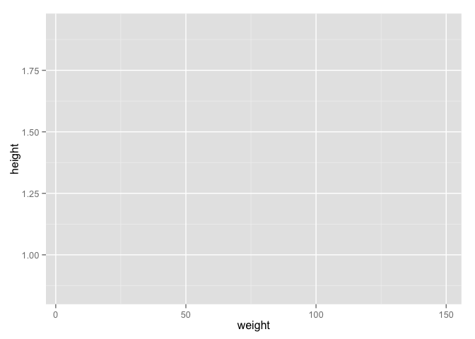

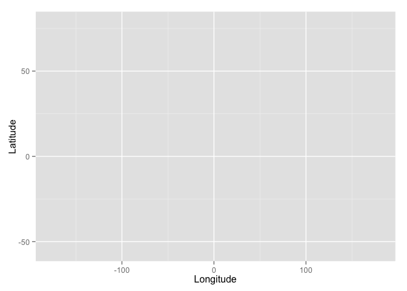

##### Frames with no graphical content

### Scales and Guides

Two other grammatical features appear in the frames drawn above, although they are so familiar that you may not have noticed them.

A **scale** describes how a value will be displayed graphically. A **guide** is an indication to a human reader of how to interpret the scale. Thus, the axis tick marks are guides. The scale translates from the data value to the position in the frame, or, as you’ll see, to other graphical properties.

### Layers

The data graphics themselves are in one or more **layers** added to the frame. In the `ggplot()` system, layers are often called “geoms,” reflecting the way they translate data to geometry.

To add a layer to a plot, use the appropriate geom for the type of graphical depiction you want. For example, the familiar scatterplot is `geom_point()`: each case will be represented by a point.

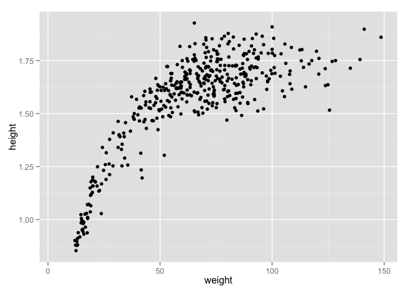

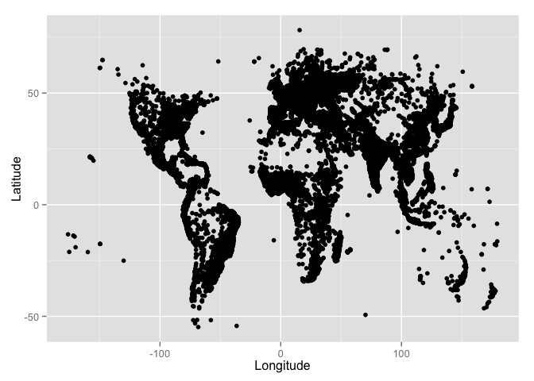

```r
frame1 + geom_point()
frame2 + geom_point()
```

Frame plus layer gives graphic.

It looks like `geom_point()` does not need any inputs. In fact, the value of the data points and the definition of how to translate data values into graphical attributes has been defined in the frame. That information is transmitted to `geom_point()` by the ‘+’ symbol.

There are many different geoms for different purposes.

### Geoms and Glyphs

The dot is a very simple glyph. You can often add more features to a glyph to encode more variables. Some of the glyph features often used in scatterplots, in addition to (x,y) position, are shape, size, and color. Assigning a variable to an attribute causes that variable to indicate the value of the variable. Here, the shape of the glyphs is set to `sex`. This creates a scale (females are dots, males are triangles) and displays a guide for the scale.

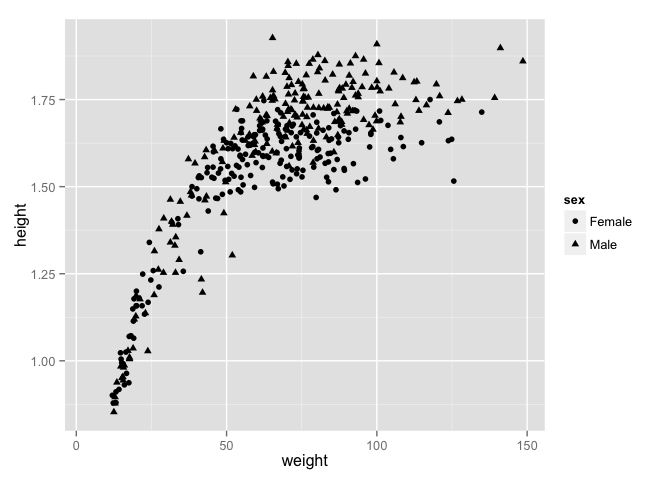

```r
frame1 + geom_point(aes(shape=sex))
```

Any or all of the glyph attributes can be set. For instance

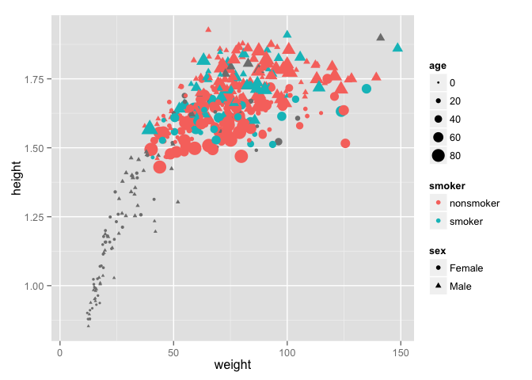

```r
frame1 + geom_point(aes(shape=sex,size=age,color=smoker))
```

##### Figure 5. Setting many glyph attributes

A point is one type of glyph. There are many others. As an example, take the `babyNamesYearly` dataset. This gives the number of births of each sex in each year in the US, along with the number of unique names assigned to those babies.

```r
data(babyNamesYearly)
head(babyNamesYearly)
```

```
## Source: local data frame [6 x 4]
## Groups: year
##
##   year sex nnames nbirths
## 1 1880   F    942   90993
## 2 1880   M   1058  110491
## 3 1881   F    938   91954
## 4 1881   M    997  100746
## 5 1882   F   1028  107850
## 6 1882   M   1099  113687
```

What would be a proper display of the number of births over time? Clearly, the frame should be number of births versus year. We can also include in the frame an assignment of sex to color.

```r
babyFrame <- ggplot( data=babyNamesYearly,
                     aes(x=year,y=nbirths,color=sex))
```

Rather than plotting the years each as individual points, it might be helpful to connect the years.

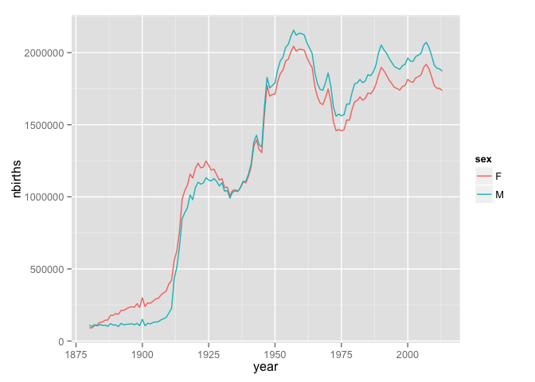

```r
babyFrame + geom_line()
```

There are other attributes that the line can have: color, linetype, size. For instance, the line thickness (`size`) can be set to indicate the number of unique names each year.

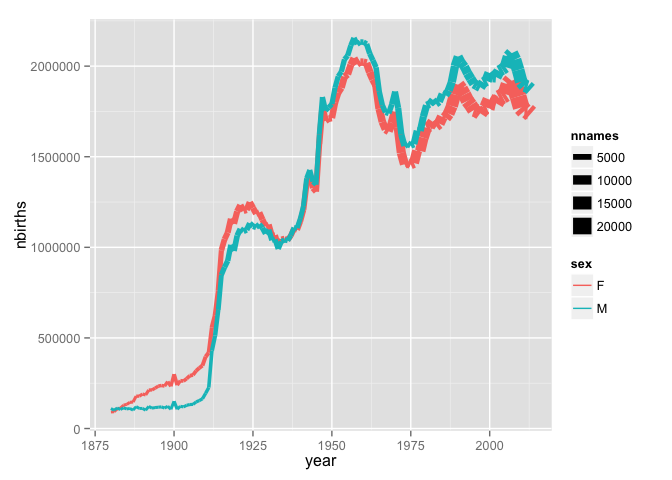

```r
babyFrame + geom_line(aes(size=nnames))
```

### Layers

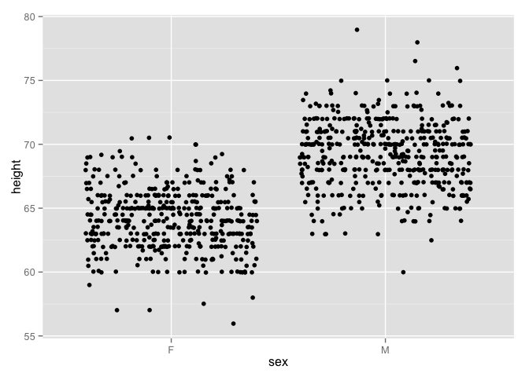

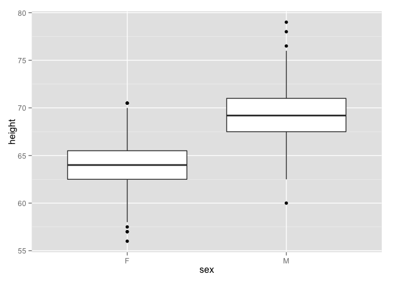

```r
frame3 <- ggplot( data=Galton, aes(x=sex, y=height) )
frame3 + geom_jitter()
frame3 + geom_boxplot()
```

The `jitter` geom spreads out the points to avoid overlaps. The `boxplot` geom draws the classical box-and-whiskers plot.

Layers made in the same frame can be put on top of one another:

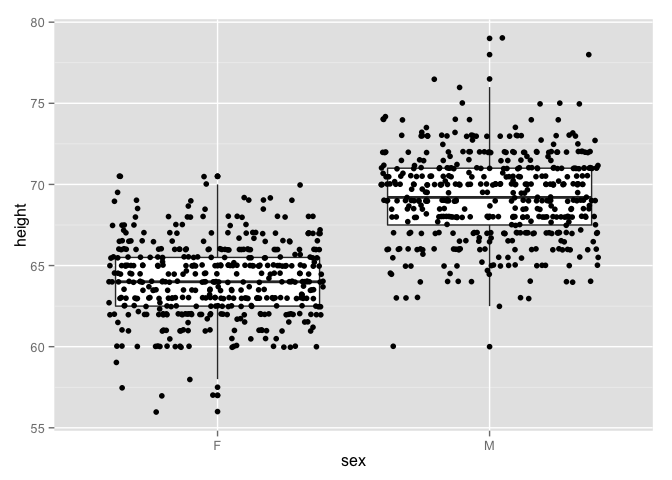

```r
frame3 + geom_boxplot() + geom_jitter()
```

#### Exercises:

- Graph the `babyNamesYearly` with number of unique names on the x-axis and using color and line thickness to indicate the number of births.
- Draw this plot from the `babyNamesYearly` data. Hints: Look at the four guides in the plot to determine what variables are being used and how. Use jittering.

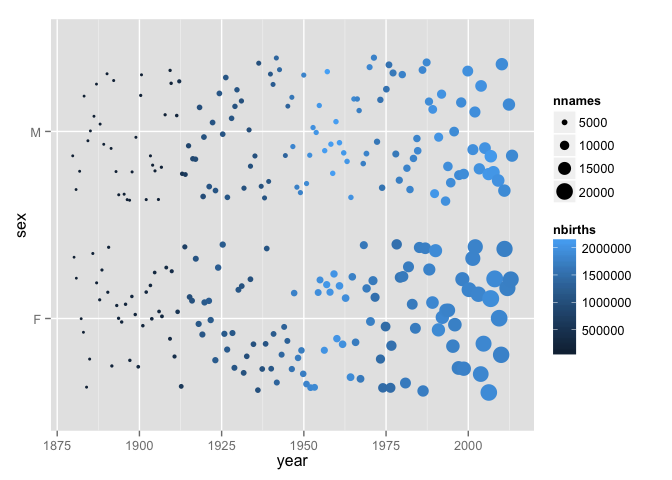

- Graph the WorldCities data, using the population to set the size. Now do it with the size as the square-root of population. Now size as color. Now size as log(color).

## Frames with Categorical Variables

The previous examples have used categorical variables to set color, size, etc. Categorical variables can also be used in the frame, defining the space in which glyphs are drawn.

Frames can use categorical variables to define the space. For instance:

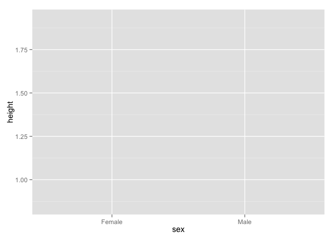

```r
frame3 <- ggplot( data=smallNHANES, aes(x=sex,y=height) )
```

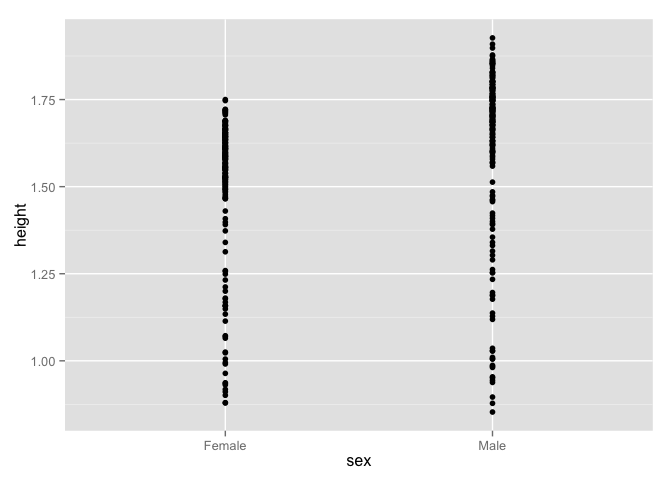

```r
frame3 + geom_point()
```

## What you should know

- What is a *frame* and how variables are used to define it.
- Some important geoms: `geom_point()`, `geom_jitter()`, `geom_line()`, …
- The most common aesthetics: x-position, y-position, size, color, shape
- How to construct a layer and add it to a plot.
- The axes with tick marks and labels for the horizontal and vertical variable.
- The “legend” showing which shape corresponds to which sex.

The most commonly used attributes in a `geom_point` are these four:

1. x position
2. y position
3. shape
4. color

Cartesian spaces.

Ordinal spaces.

BAR PLOT in cartesian and radial coordinates. A dot plot in spiral coordinates.

Illustration of how we can be oblivious to elements of a graphic depending on how they are presented. [Cross-written letter from Charles Darwin](http://blog.paperblanks.com/2013/03/cross-writing/)

[figure not shown]

As you’ll see, it can help to have more general categories. The categories and components to be used here may seem at first to be abstract and counter-intuitive. For instance, scatterplots, bar plots, pie charts and maps are all different forms of the same kind of entity, even though they look very different.

### Frames and Glyphs

Maybe it’s old fashioned, but start with a piece of paper. You’re going to draw a data-driven graphic, and you have the data at hand in the form of a data table, for instance:

| Age | Height | Sex | Sport |
| --- | --- | --- | --- |
| 34 | 180 | M | Basketball |

and so on.

Before you do any drawing, you have to decide what position on the paper means. This is called the **frame** of the graphic. It’s likely that you’ve seen a particular kind of frame, the *cartesian coordinate system*. In this frame, horizontal position means one thing, vertical position another. In mathematics a Cartesian frame is often drawn like this:

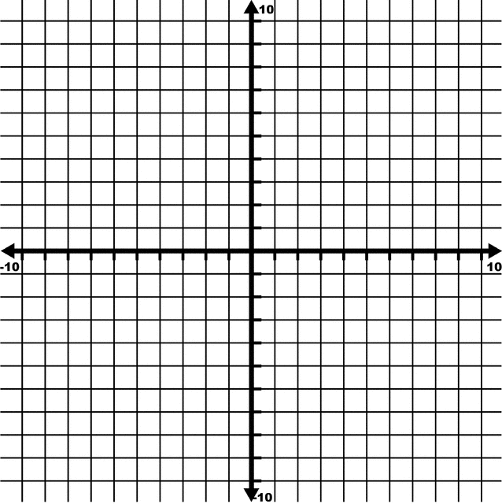

or, without the grid, like this:

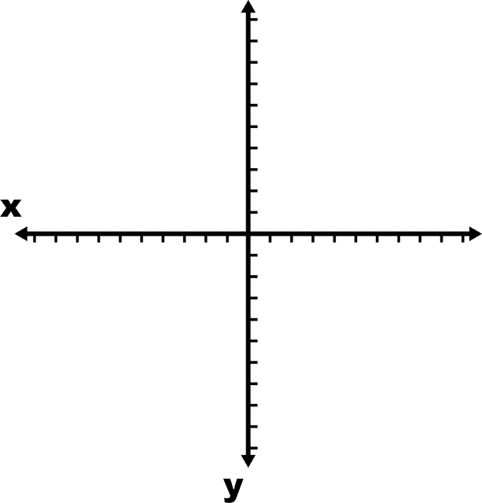

An example of a frame for data-driven graphics:

[figure not shown]

Such Cartesian coordinates are very common in graphics, but there are others. In the following graphic, position on the vertical axis represents the concentration of enzyme: a quantity. Position along the horizontal axis represents a quality or category: a particular gene.

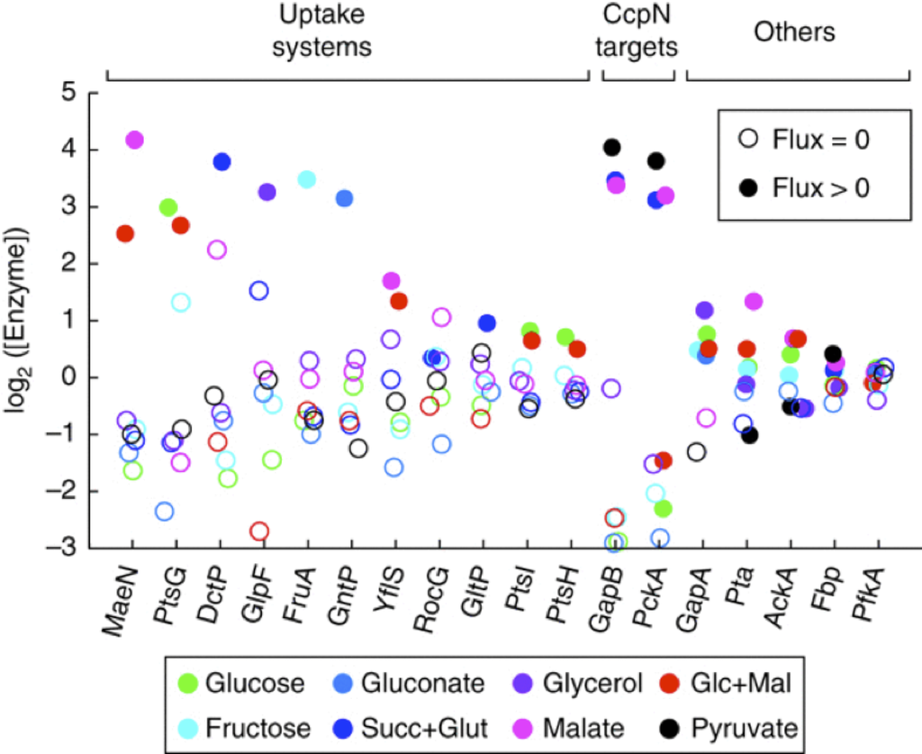

Of course, a gene is itself not a position on a paper. Position is being used metaphorically to stand for gene. The frame establishes how position corresponds to gene.

Sometimes, the frame is based on physical position. For instance, in this graphic the position on the paper corresponds to a position on the surface of the Earth.

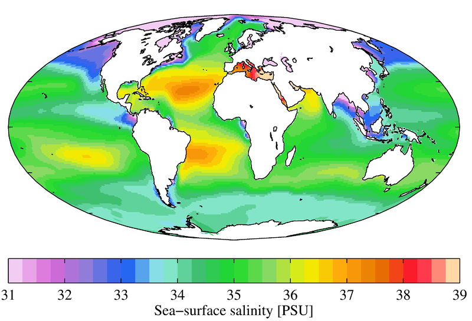

#### Callout

Radial coordinates. Still two values give position. The pie chart.

Map projections.

#### CALLOUT

Three-dimensional frames. How three variables can be represented on a piece of paper.

### Three basic kinds of graphics

Data-driven graphics relate data to graphical elements. That’s obvious. A useful basic categorization of “kinds of graphics,” will consider the structure of data and how that structure relates to the structure of the graphics, in particular to glyphs and frames.

Remember that data, as the word is used here, consists of cases and variables. The characterization of graphics in terms of data must identify the roles played by cases and variables. It might not be what you are expecting.

#### Two (or more) cases per glyphs

#### Fields and the collective features of data

- A histogram is a kind of field. There are others.

### Other elements of graphics

- Guide
- Scale
- Axis